# Variance

## Definition

For random variable $X$ with mean $\mu$, the variance of $X$ is:

$$Var(X) = E[(X - \mu)^2] = E[X^2] - E[X]^2$$

The square root of the variance is the standard deviation.

## Binomial Variance Example

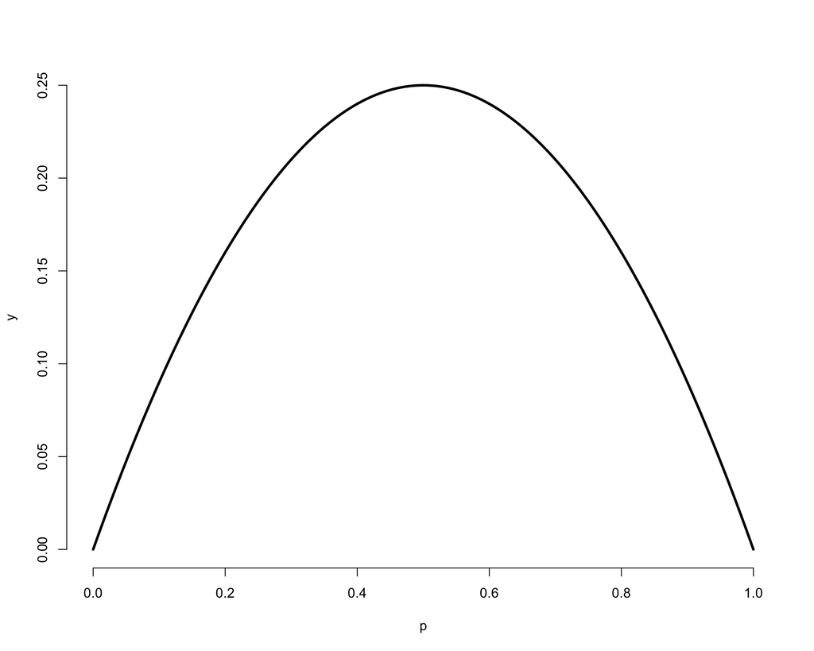

```r
p = seq(0 , 1, length = 1000)
y = p * (1 - p)
plot(p, y, type = "l", lwd = 3, frame = FALSE)
```

```r
p.die <- rep(1/6,6)
sum(p.die)
```

```
## [1] 1
```

```r
die <- 1:6
sample(die, size=10, prob=p.die, replace=T)
```

```
##  [1] 3 3 6 3 2 5 6 5 1 5
```

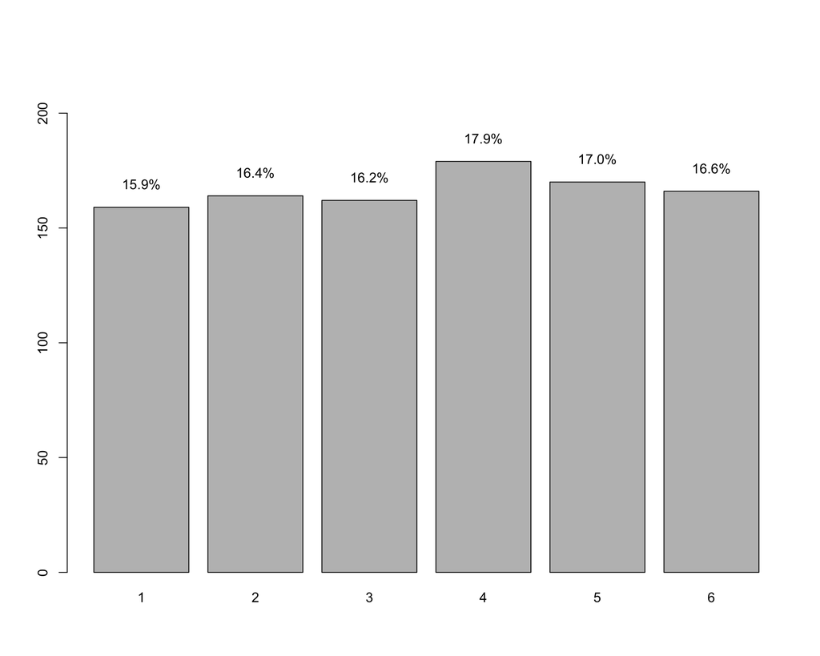

```r
s <- table(sample(die, size=1000, prob=p.die, replace=T))
lbls = sprintf("%0.1f%%", s/sum(s)*100)
barX <- barplot(s, ylim=c(0,220))
text(x=barX, y=s+10, label=lbls)
```

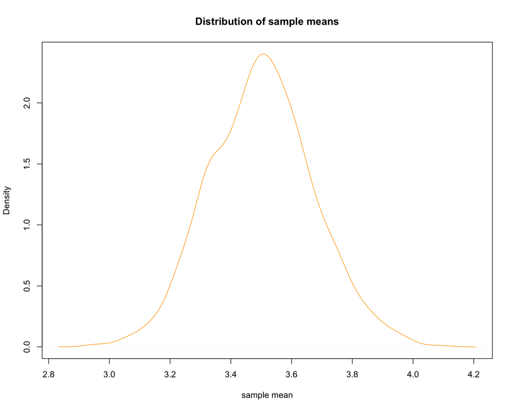

```r
generate.sample.means <- function(n) {
  sample.means <- numeric()
  for (i in 1:1000) {
    sample.means <- append(sample.means, sum(sample(die, size=n, prob=p.die, replace=T))/n)
  }
  return (sample.means)
}
sample.means <- generate.sample.means(100)
plot(density(sample.means), main="Distribution of sample means",xlab="sample mean", col="orange")
```

## Summary

- Sample variance, $S^2$, estimates the population variance, $\sigma^2$
- Distribution of sample variance $S^2$ is centered around $\sigma^2$
- Variance of the sample mean, $Var(\bar{X})$, is $\dfrac{\sigma^2}{n}$
  - Logical estimate is $\dfrac{S^2}{n}$
  - Logical estimate of the standard error is $\sqrt{\dfrac{S^2}{n}} = \dfrac{S}{\sqrt{n}}$
- Standard deviation, $S$, tells us how variable the population is
- The standard error, $\dfrac{S}{\sqrt{n}}$, tells us how much averages of random samples of size $n$ from the population vary

$$Var(\bar{X}) = Var( \dfrac{\sum X_i}{n}) = \dfrac{1}{n^2}Var(\sum_{i=1}^{n}X_i) = \dfrac{1}{n^2}\sum_{i=1}^{n}{\sigma^2} = \dfrac{n {\sigma^2}}{n^2} = \dfrac{\sigma^2}{n}$$

Chebyshev’s inequality helps interpret variances. It states that the probability that a random variable X is at least k standard deviations | from its mean is less than 1/(k^2). In other words, the probability that X is at least 2 standard deviations from the mean is less than 1/4, 3 standard deviations 1/9, 4 standard | deviations 1/16, etc.